# An R Markdown document converted from “C:/Users/Dis/Downloads/anagramm.ipynb”

### Сравнение вероятности возникновения интрузий в экспериментальной группе в зависимости от типа наводки и точности на первом этапами

#### Отсев

```r
full_data %>%
  filter(group == "эксп" & dropout_intr == 0) -> vers_data
```

#### Кол-во проб

```r
vers_data %>% nrow()
```

```
## [1] 5011
```

#### Смешанная модель

```r
vers_data$Condition <- vers_data$Condition %>% as.factor()
vers_data$Accuracy <-vers_data$Accuracy %>% as.factor()
vers_data$intrusion <-vers_data$intrusion %>% as.factor()
vers_data <- within(vers_data, Condition <- relevel(Condition, ref = 2))
vers_data <- within(vers_data, Accuracy <- relevel(Accuracy, ref = 1))

vers_mdl_1 <- glmer(
                intrusion ~ Condition*Accuracy + (1|ID) + (1|Answer.Corr),
                vers_data,
                family = binomial)
summary(vers_mdl_1)
```

```
## Generalized linear mixed model fit by maximum likelihood (Laplace
##   Approximation) [glmerMod]
##  Family: binomial  ( logit )
## Formula: intrusion ~ Condition * Accuracy + (1 | ID) + (1 | Answer.Corr)
##    Data: vers_data
##
##      AIC      BIC   logLik deviance df.resid
##   4358.6   4397.7  -2173.3   4346.6     5005
##
## Scaled residuals:
##     Min      1Q  Median      3Q     Max
## -2.0392 -0.4759 -0.3162 -0.1824  7.0802
##
## Random effects:
##  Groups      Name        Variance Std.Dev.
##  Answer.Corr (Intercept) 1.1507   1.0727
##  ID          (Intercept) 0.2345   0.4842
## Number of obs: 5011, groups:  Answer.Corr, 78; ID, 65
##
## Fixed effects:
##                      Estimate Std. Error z value Pr(>|z|)
## (Intercept)           -1.6753     0.1647 -10.173  < 2e-16 ***
## Condition1             0.3175     0.1184   2.682  0.00731 **
## Accuracy1             -0.2970     0.1204  -2.466  0.01365 *
## Condition1:Accuracy1  -0.3461     0.1587  -2.181  0.02920 *
## ---
## Signif. codes:  0 '***' 0.001 '**' 0.01 '*' 0.05 '.' 0.1 ' ' 1
##
## Correlation of Fixed Effects:
##             (Intr) Cndtn1 Accrc1
## Condition1  -0.388
## Accuracy1   -0.420  0.532
## Cndtn1:Acc1  0.291 -0.753 -0.681
```

```r
vers_mdl_1 %>% summ()
```

```
## MODEL INFO:
## Observations: 5011
## Dependent Variable: intrusion
## Type: Mixed effects generalized linear regression
## Error Distribution: binomial
## Link function: logit
##
## MODEL FIT:
## AIC = 4358.62, BIC = 4397.73
## Pseudo-R² (fixed effects) = 0.01
## Pseudo-R² (total) = 0.31
##
## FIXED EFFECTS:
## ---------------------------------------------------------
##                               Est.   S.E.   z val.      p
## -------------------------- ------- ------ -------- ------
## (Intercept)                  -1.68   0.16   -10.17   0.00
## Condition1                    0.32   0.12     2.68   0.01
## Accuracy1                    -0.30   0.12    -2.47   0.01
## Condition1:Accuracy1         -0.35   0.16    -2.18   0.03
## ---------------------------------------------------------
##
## RANDOM EFFECTS:
## ---------------------------------------
##     Group       Parameter    Std. Dev.
## ------------- ------------- -----------
##  Answer.Corr   (Intercept)     1.07
##      ID        (Intercept)     0.48
## ---------------------------------------
##
## Grouping variables:
## -------------------------------
##     Group      # groups   ICC
## ------------- ---------- ------
##  Answer.Corr      78      0.25
##      ID           65      0.05
## -------------------------------
```

Оценка Cooks’ distance (Это мера того, насколько изменяются предсказания модели, если исключить одно наблюдение.)

```r
cooksd <- cooks.distance(vers_mdl_1)
```

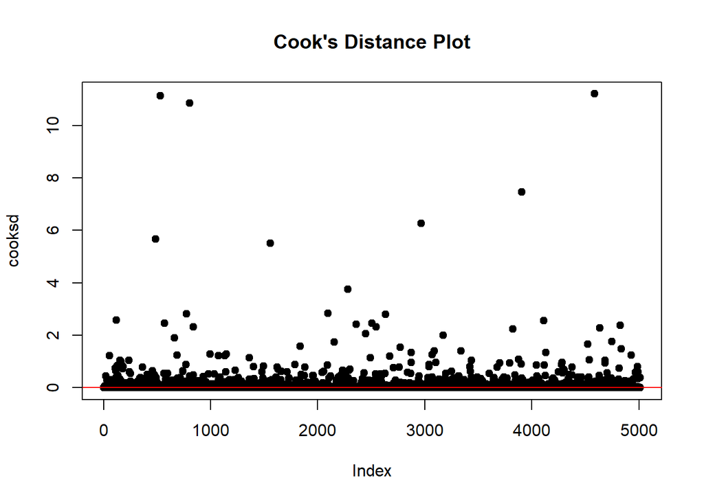

```r
plot(cooksd, pch = 19, main = "Cook's Distance Plot")
abline(h = 4/length(cooksd), col = "red")  # Пороговая линия
```

```r
print(which(cooksd > 1))  # Номера строк в данных
```

```
##   54  118  154  164  237  485  532  568  662  686  775  804  837  997 1073 1132
##   54  118  154  164  237  485  532  568  662  686  775  804  837  997 1073 1132
## 1146 1360 1555 1836 2096 2152 2281 2358 2450 2492 2505 2547 2634 2675 2773 2874
## 1146 1360 1555 1836 2096 2152 2281 2358 2450 2492 2505 2547 2634 2675 2773 2874
## 2966 3068 3087 3170 3336 3436 3824 3875 3904 4112 4131 4521 4536 4587 4637 4684
## 2966 3068 3087 3170 3336 3436 3824 3875 3904 4112 4131 4521 4536 4587 4637 4684
## 4746 4828 4836 4927
## 4746 4828 4836 4927
```

```r
vers_mdl_2 <- glmer(
                intrusion ~ Condition*Accuracy + (1|ID) + (1|Answer.Corr),
                vers_data[which(cooksd < 1), ],
                family = binomial)
summary(vers_mdl_2)
```

```
## Generalized linear mixed model fit by maximum likelihood (Laplace
##   Approximation) [glmerMod]
##  Family: binomial  ( logit )
## Formula: intrusion ~ Condition * Accuracy + (1 | ID) + (1 | Answer.Corr)
##    Data: vers_data[which(cooksd < 1), ]
##
##      AIC      BIC   logLik deviance df.resid
##   4016.2   4055.3  -2002.1   4004.2     4953
##
## Scaled residuals:
##     Min      1Q  Median      3Q     Max
## -2.1358 -0.4692 -0.2750 -0.1051  4.3547
##
## Random effects:
##  Groups      Name        Variance Std.Dev.
##  Answer.Corr (Intercept) 2.3931   1.5470
##  ID          (Intercept) 0.2997   0.5475
## Number of obs: 4959, groups:  Answer.Corr, 78; ID, 65
##
## Fixed effects:
##                      Estimate Std. Error z value Pr(>|z|)
## (Intercept)           -2.0226     0.2171  -9.318  < 2e-16 ***
## Condition1             0.3637     0.1236   2.941  0.00327 **
## Accuracy1             -0.3124     0.1264  -2.472  0.01343 *
## Condition1:Accuracy1  -0.4222     0.1661  -2.541  0.01105 *
## ---
## Signif. codes:  0 '***' 0.001 '**' 0.01 '*' 0.05 '.' 0.1 ' ' 1
##
## Correlation of Fixed Effects:
##             (Intr) Cndtn1 Accrc1
## Condition1  -0.313
## Accuracy1   -0.333  0.533
## Cndtn1:Acc1  0.234 -0.752 -0.678
```

После исключения самых влиятельных наблюдений - значения предикторов остаются с теми же знаками и не теряют значимость. Таким образом выбросы - не значительно влияют на модель.

#### График

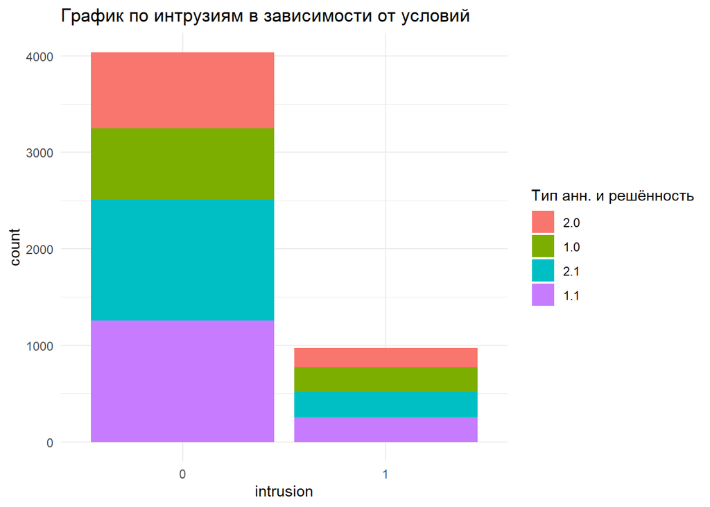

```r
vers_data$interaction <- interaction(vers_data$Condition, vers_data$Accuracy)
vers_data %>%
  ggplot(aes(x = intrusion, fill = factor(interaction))) +
    geom_bar() +
    theme_minimal() +
    labs(
      title = "График по интрузиям в зависимости от условий",
      ylab = "Количество проб",
      fill = "Тип анн. и решённость"
    )
```

### Анализ вероятности возникновения интрузий на втором этапе в зависимости от отчёта об ага-переживании в экспериментальной группе.

#### Отсев

```r
full_data %>%
  filter(group == "эксп" & dropout_intr == 0 & Accuracy == 1 & Q1Aha.RESP != 3) -> vers_data
```

#### Кол-во проб

```r
vers_data %>% nrow()
```

```
## [1] 3005
```

#### Смешанная модель

```r
vers_data$Condition <- vers_data$Condition %>% as.factor()
vers_data$Q1Aha.RESP <-vers_data$Q1Aha.RESP %>% as.factor()
vers_data <- within(vers_data, Condition <- relevel(Condition, ref = 2))
vers_data <- within(vers_data, Q1Aha.RESP <- relevel(Q1Aha.RESP, ref = 2))

vers_mdl_2 <- glmer(
                intrusion ~ Condition*Q1Aha.RESP + (1|ID) + (1|Answer.Corr),
                vers_data,
                family = binomial)
vers_mdl_2 %>% summary()
```

```
## Generalized linear mixed model fit by maximum likelihood (Laplace
##   Approximation) [glmerMod]
##  Family: binomial  ( logit )
## Formula: intrusion ~ Condition * Q1Aha.RESP + (1 | ID) + (1 | Answer.Corr)
##    Data: vers_data
##
##      AIC      BIC   logLik deviance df.resid
##   2449.8   2485.9  -1218.9   2437.8     2999
##
## Scaled residuals:
##     Min      1Q  Median      3Q     Max
## -1.5967 -0.4373 -0.2860 -0.1880  6.5032
##
## Random effects:
##  Groups      Name        Variance Std.Dev.
##  Answer.Corr (Intercept) 1.3322   1.1542
##  ID          (Intercept) 0.2084   0.4566
## Number of obs: 3005, groups:  Answer.Corr, 78; ID, 65
##
## Fixed effects:
##                        Estimate Std. Error z value Pr(>|z|)
## (Intercept)            -2.02665    0.18234 -11.115   <2e-16 ***
## Condition1             -0.06373    0.14495  -0.440    0.660
## Q1Aha.RESP1             0.10667    0.15523   0.687    0.492
## Condition1:Q1Aha.RESP1  0.03392    0.21311   0.159    0.874
## ---
## Signif. codes:  0 '***' 0.001 '**' 0.01 '*' 0.05 '.' 0.1 ' ' 1
##
## Correlation of Fixed Effects:
##             (Intr) Cndtn1 Q1A.RE
## Condition1  -0.386
## Q1Aha.RESP1 -0.394  0.460
## C1:Q1A.RESP  0.264 -0.685 -0.675
```

```r
vers_mdl_2 %>% summ()
```

```
## MODEL INFO:
## Observations: 3005
## Dependent Variable: intrusion
## Type: Mixed effects generalized linear regression
## Error Distribution: binomial
## Link function: logit
##
## MODEL FIT:
## AIC = 2449.80, BIC = 2485.85
## Pseudo-R² (fixed effects) = 0.00
## Pseudo-R² (total) = 0.32
##
## FIXED EFFECTS:
## -----------------------------------------------------------
##                                 Est.   S.E.   z val.      p
## ---------------------------- ------- ------ -------- ------
## (Intercept)                    -2.03   0.18   -11.11   0.00
## Condition1                     -0.06   0.14    -0.44   0.66
## Q1Aha.RESP1                     0.11   0.16     0.69   0.49
## Condition1:Q1Aha.RESP1          0.03   0.21     0.16   0.87
## -----------------------------------------------------------
##
## RANDOM EFFECTS:
## ---------------------------------------
##     Group       Parameter    Std. Dev.
## ------------- ------------- -----------
##  Answer.Corr   (Intercept)     1.15
##      ID        (Intercept)     0.46
## ---------------------------------------
##
## Grouping variables:
## -------------------------------
##     Group      # groups   ICC
## ------------- ---------- ------
##  Answer.Corr      78      0.28
##      ID           65      0.04
## -------------------------------
```

# Сохранение данных

## Сохранение таблицы с данными

```r
full_data$dropout_all <- 0
full_data[!is.na(full_data$dropout_1) & full_data$dropout_1 == 1, ]$dropout_all <- 1

full_data[!is.na(full_data$dropout_2) & full_data$dropout_2 == 1, ]$dropout_all <- 1

if(nrow(full_data[!is.na(full_data$exclude) & full_data$exclude == 1, ]) > 0)
  full_data[!is.na(full_data$exclude) & full_data$exclude == 1, ]$dropout_all <- 1


write.csv(full_data, "full_data.csv")
```